# Clase Introducción 14 Ene 26

2026-01-15

```r
2+3
```

```
## [1] 5
```

```r
library(quantmod)
getSymbols("TSLA", from = "2019-11-29" )
```

```
## [1] "TSLA"
```

```r
getSymbols("AAPL", from = "2019-11-29" , to = "2023-11-29")
```

```
## [1] "AAPL"
```

```r
getSymbols("^SPX", from = "2019-11-29")
```

```
## [1] "SPX"
```

```r
getSymbols("BAC", from = "2019-11-29", to = "2022-11-29")
```

```
## [1] "BAC"
```

```r
getSymbols("AMZN", from = "2019-11-29", to = "2024-11-29")
```

```
## [1] "AMZN"
```

```r
tsla1 <- (TSLA$TSLA.Close)
```

```r
tsla_apertura <- (TSLA$TSLA.Open)
```

```r
amzn1 <- (AMZN$AMZN.Close)
```

```r
amzn2 <- (AMZN$AMZN.Open)
```

```r
tsla1 <- na.omit(tsla1)
```

```r
amzn1 <- na.omit(amzn1)
```

```r
amzn2 <- na.omit(amzn2)
```

## Daily returns

Se utiliza para obtener los rendimientos diarios de una acción

```r
tsla1_returns <- dailyReturn(tsla1)
```

```r
amzn1_returns <- dailyReturn(amzn1)
```

## Analizando rendimientos de las acciones

Plot, función que grafica de manera lineal, es la base para graficar. Main, es el título, se pone entre comillas. Show in new window, lo abre en una página externa, y se puede observar de mejor manera.

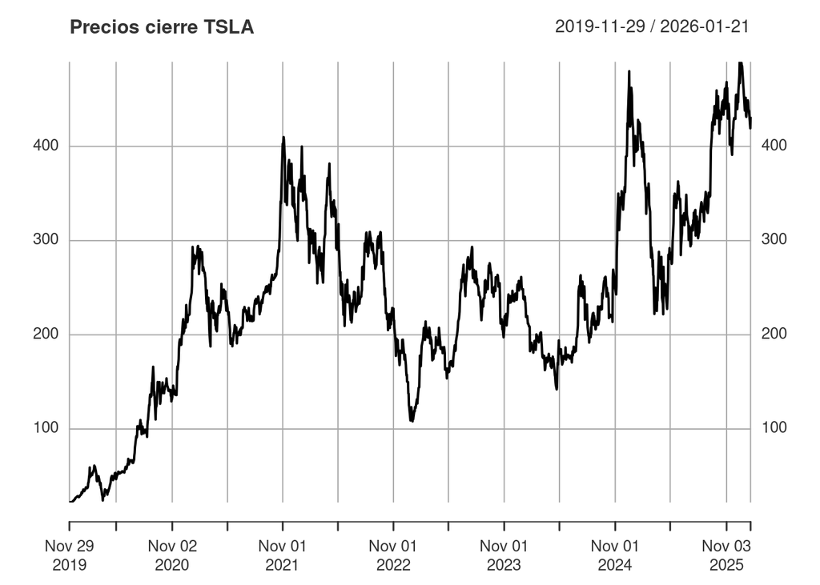

```r
plot(tsla1, main = "Precios cierre TSLA")
```

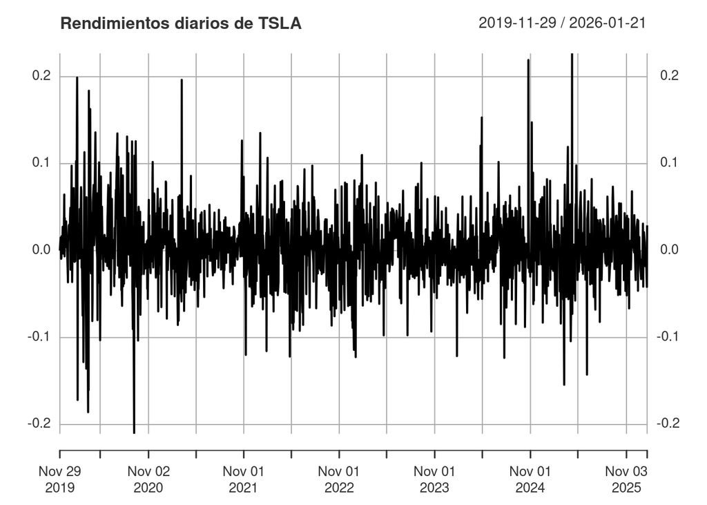

```r
plot(tsla1_returns, main = "Rendimientos diarios de TSLA" )
```

# Histogram

probability-Probabilidad ylim-Rango en y

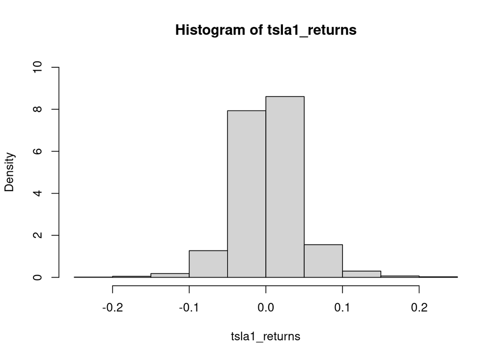

```r
hist(tsla1_returns, probability = TRUE, ylim = c(0, 10))
```

# Boxplot

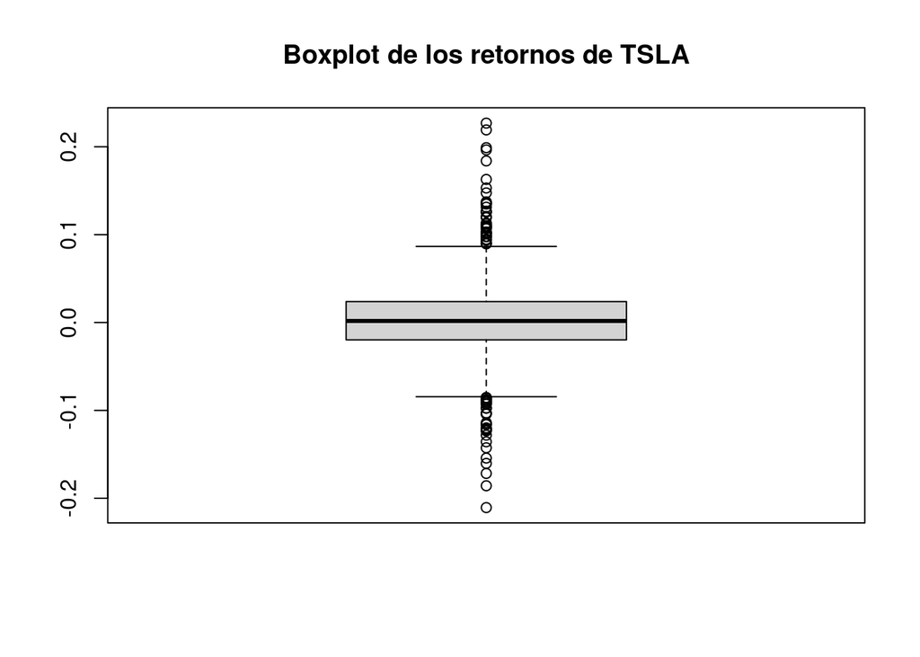

```r
boxplot(tsla1_returns, main = "Boxplot de los retornos de TSLA")
```

## cálculo de retornos anuales

Nueva variable annualReturn leading-no tomar en cuenta letras, solo números con FALSE

```r
tsla1_returns_annual <- annualReturn(tsla1, leading = FALSE )
```

# Gráfica de barras

Le puedes agregar un nombre a la gráfica con el main.

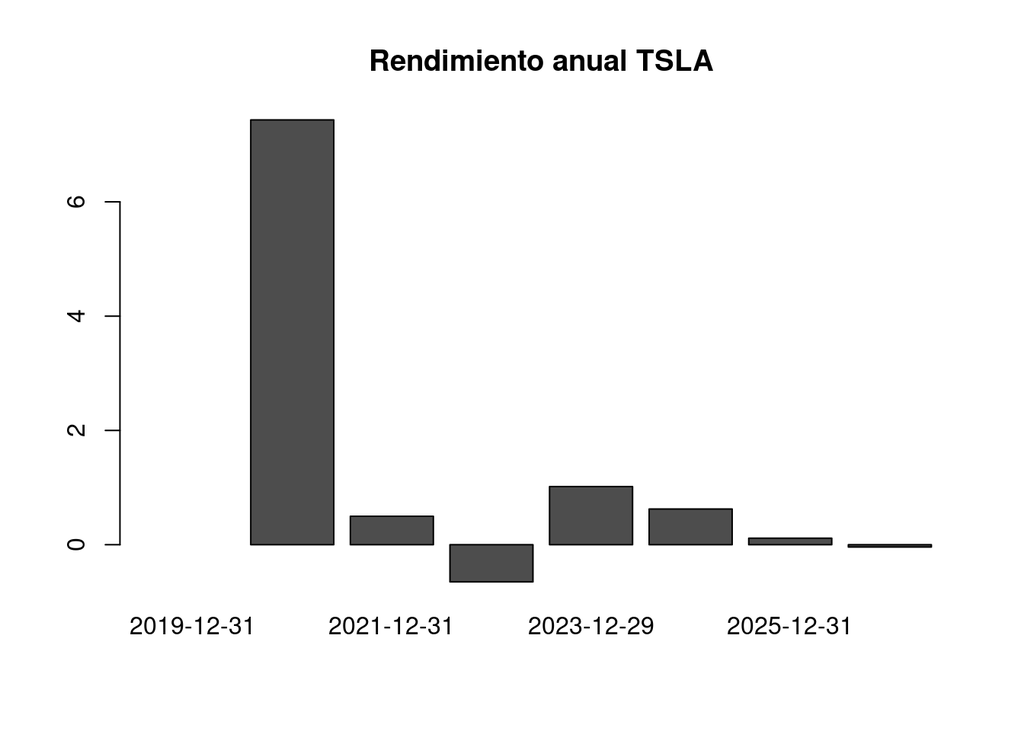

```r
barplot(tsla1_returns_annual, main= "Rendimiento anual TSLA")
```

# Ejercicio de clase

Realizar todas las gráficas con AMZN

Plot amzn

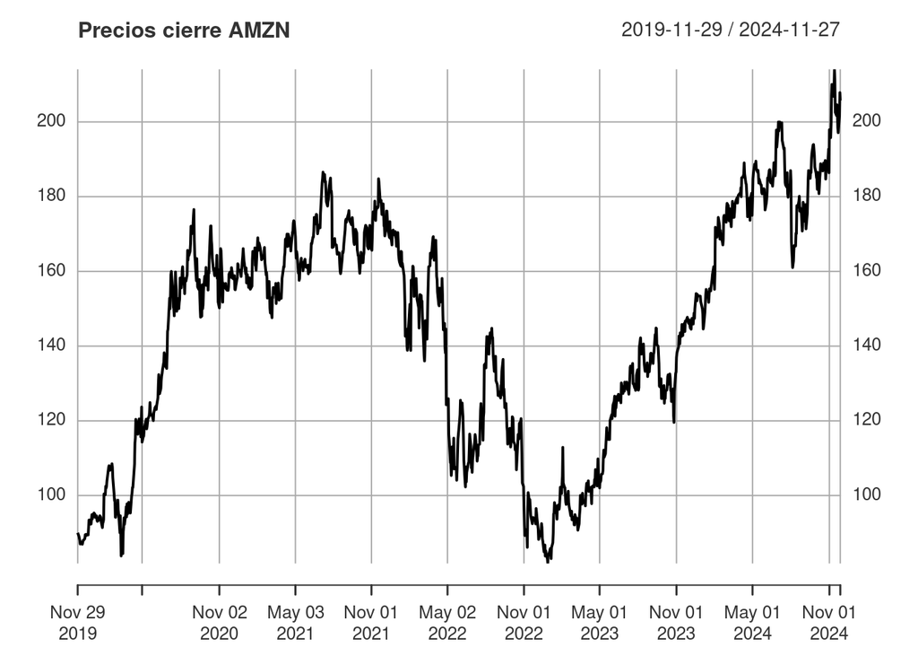

```r
plot(amzn1, main = "Precios cierre AMZN")
```

# Rendimientos diarios de AMZN

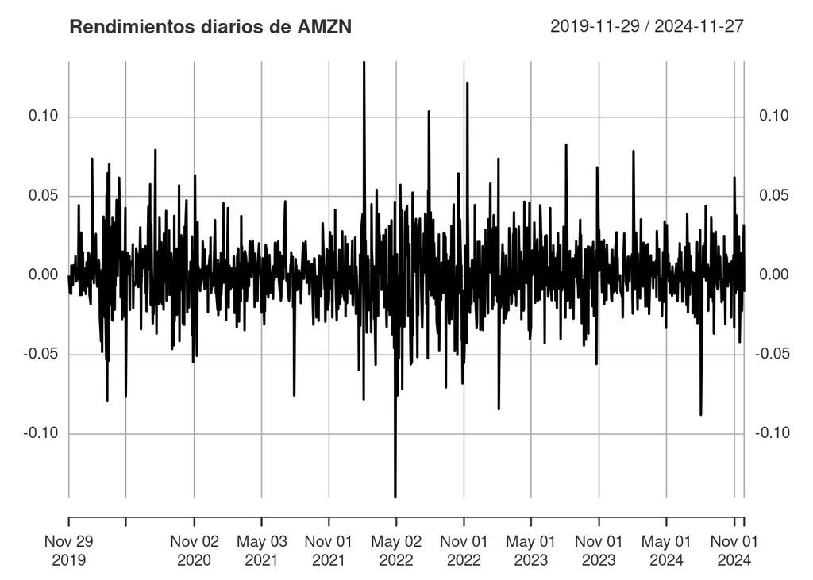

```r
plot(amzn1_returns, main = "Rendimientos diarios de AMZN" )
```

# Histograma de AMZN

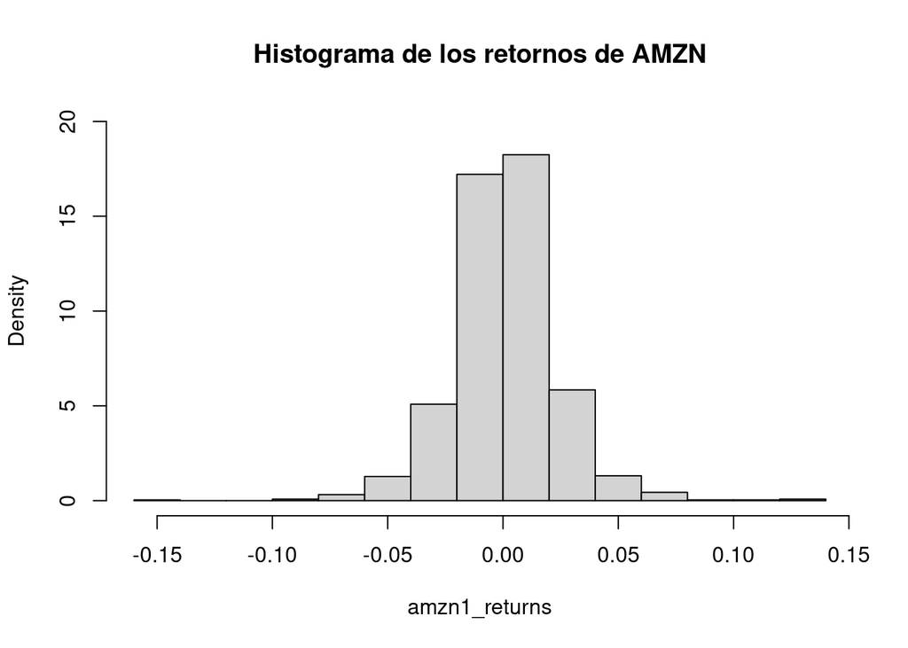

```r
hist(amzn1_returns, probability = TRUE, ylim = c(0, 20), main = "Histograma de los retornos de AMZN")
```

# boxplot AMZN

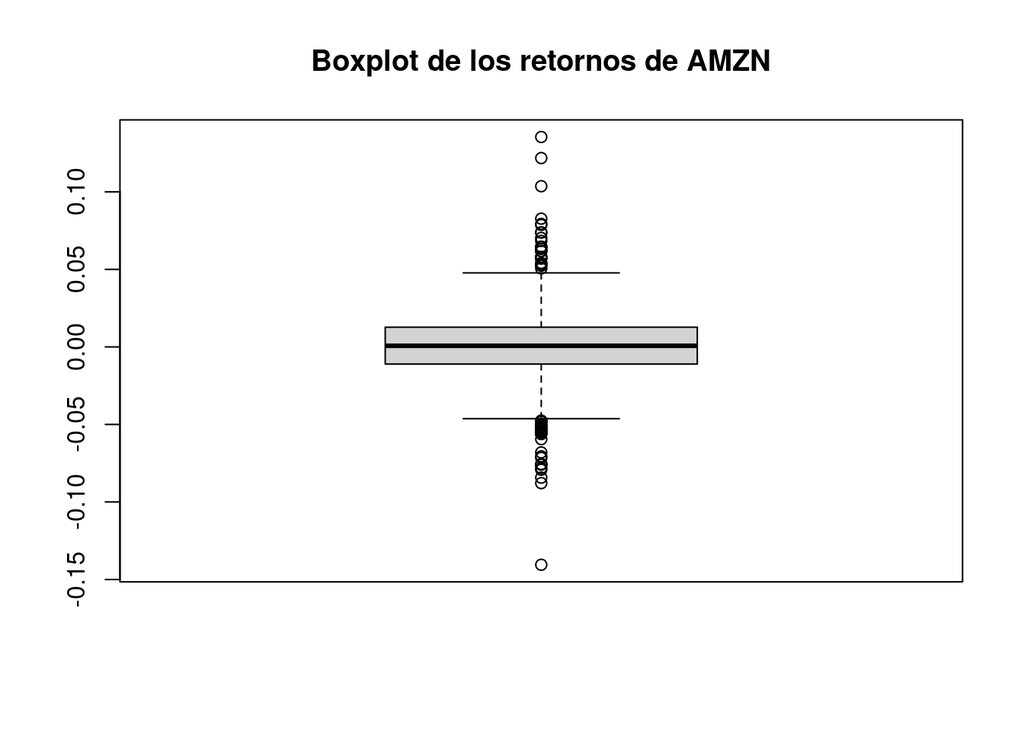

```r
boxplot(amzn1_returns, main = "Boxplot de los retornos de AMZN")
```

# Cálculo de los retornos anuales AMZN

```r
amzn1_returns_annual <- annualReturn(amzn1, leading = FALSE )
```

# Gráfica de barras rendimiento anual AMZN

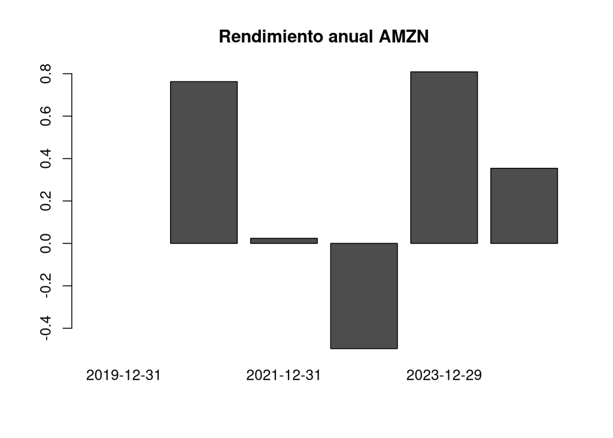

```r
barplot(amzn1_returns_annual, main= "Rendimiento anual AMZN")
```

## Regresión Lineal Simple

```r
library(MASS)
library(ISLR)
```

# data

En HELP, podemos buscar data y descargar bases de datos que tiene R históricas. Hay que darle doble click cuando aparezca la base de datos como valores, después la buscas en HELP y te arroja los detalles de esa base de datos.

Variable dummy o dicotómica, categorizas numericamente (0 o 1)

```r
data(Boston)
```

?-HELP

```r
?Boston
```

Head-Para que te aparezcan el nombre de las columnas

```r
head(Boston, 5)
```

```
##      crim zn indus chas   nox    rm  age    dis rad tax ptratio  black lstat
## 1 0.00632 18  2.31    0 0.538 6.575 65.2 4.0900   1 296    15.3 396.90  4.98
## 2 0.02731  0  7.07    0 0.469 6.421 78.9 4.9671   2 242    17.8 396.90  9.14
## 3 0.02729  0  7.07    0 0.469 7.185 61.1 4.9671   2 242    17.8 392.83  4.03
## 4 0.03237  0  2.18    0 0.458 6.998 45.8 6.0622   3 222    18.7 394.63  2.94
## 5 0.06905  0  2.18    0 0.458 7.147 54.2 6.0622   3 222    18.7 396.90  5.33
##   medv
## 1 24.0
## 2 21.6
## 3 34.7
## 4 33.4
## 5 36.2
```

str- estructura, presenta un diagnóstico resumido

```r
str(Boston)
```

```
## 'data.frame':    506 obs. of  14 variables:
##  $ crim   : num  0.00632 0.02731 0.02729 0.03237 0.06905 ...
##  $ zn     : num  18 0 0 0 0 0 12.5 12.5 12.5 12.5 ...
##  $ indus  : num  2.31 7.07 7.07 2.18 2.18 2.18 7.87 7.87 7.87 7.87 ...
##  $ chas   : int  0 0 0 0 0 0 0 0 0 0 ...
##  $ nox    : num  0.538 0.469 0.469 0.458 0.458 0.458 0.524 0.524 0.524 0.524 ...
##  $ rm     : num  6.58 6.42 7.18 7 7.15 ...
##  $ age    : num  65.2 78.9 61.1 45.8 54.2 58.7 66.6 96.1 100 85.9 ...
##  $ dis    : num  4.09 4.97 4.97 6.06 6.06 ...
##  $ rad    : int  1 2 2 3 3 3 5 5 5 5 ...
##  $ tax    : num  296 242 242 222 222 222 311 311 311 311 ...
##  $ ptratio: num  15.3 17.8 17.8 18.7 18.7 18.7 15.2 15.2 15.2 15.2 ...
##  $ black  : num  397 397 393 395 397 ...
##  $ lstat  : num  4.98 9.14 4.03 2.94 5.33 ...
##  $ medv   : num  24 21.6 34.7 33.4 36.2 28.7 22.9 27.1 16.5 18.9 ...
```

summary- Resumen estadístico de cada variable

```r
summary(Boston)
```

```
##       crim                zn             indus            chas
##  Min.   : 0.00632   Min.   :  0.00   Min.   : 0.46   Min.   :0.00000
##  1st Qu.: 0.08205   1st Qu.:  0.00   1st Qu.: 5.19   1st Qu.:0.00000
##  Median : 0.25651   Median :  0.00   Median : 9.69   Median :0.00000
##  Mean   : 3.61352   Mean   : 11.36   Mean   :11.14   Mean   :0.06917
##  3rd Qu.: 3.67708   3rd Qu.: 12.50   3rd Qu.:18.10   3rd Qu.:0.00000
##  Max.   :88.97620   Max.   :100.00   Max.   :27.74   Max.   :1.00000
##       nox               rm             age              dis
##  Min.   :0.3850   Min.   :3.561   Min.   :  2.90   Min.   : 1.130
##  1st Qu.:0.4490   1st Qu.:5.886   1st Qu.: 45.02   1st Qu.: 2.100
##  Median :0.5380   Median :6.208   Median : 77.50   Median : 3.207
##  Mean   :0.5547   Mean   :6.285   Mean   : 68.57   Mean   : 3.795
##  3rd Qu.:0.6240   3rd Qu.:6.623   3rd Qu.: 94.08   3rd Qu.: 5.188
##  Max.   :0.8710   Max.   :8.780   Max.   :100.00   Max.   :12.127
##       rad              tax           ptratio          black
##  Min.   : 1.000   Min.   :187.0   Min.   :12.60   Min.   :  0.32
##  1st Qu.: 4.000   1st Qu.:279.0   1st Qu.:17.40   1st Qu.:375.38
##  Median : 5.000   Median :330.0   Median :19.05   Median :391.44
##  Mean   : 9.549   Mean   :408.2   Mean   :18.46   Mean   :356.67
##  3rd Qu.:24.000   3rd Qu.:666.0   3rd Qu.:20.20   3rd Qu.:396.23
##  Max.   :24.000   Max.   :711.0   Max.   :22.00   Max.   :396.90
##      lstat            medv
##  Min.   : 1.73   Min.   : 5.00
##  1st Qu.: 6.95   1st Qu.:17.02
##  Median :11.36   Median :21.20
##  Mean   :12.65   Mean   :22.53
##  3rd Qu.:16.95   3rd Qu.:25.00
##  Max.   :37.97   Max.   :50.00
```

pairs- matriz de gráficas de dispersión

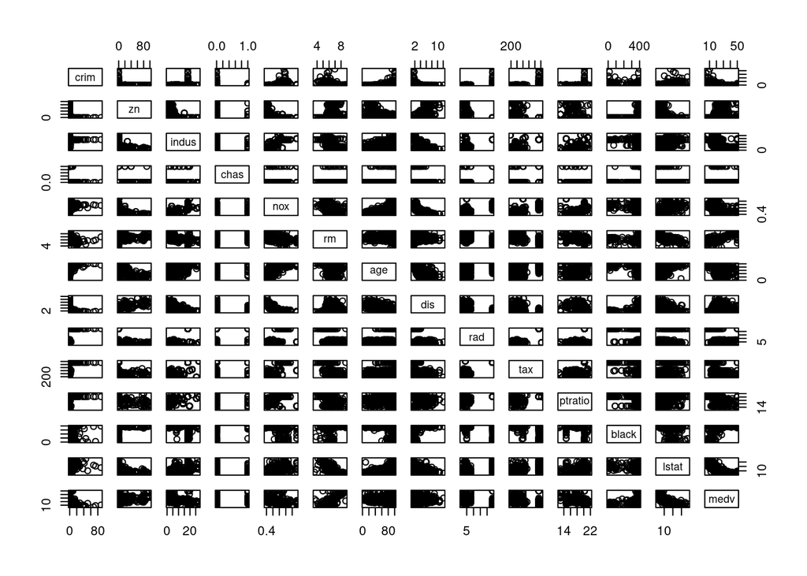

```r
pairs(Boston)
```

attach- Pegar la base de datos en el markdown no en variables

```r
attach(Boston)
```

Plot- En R el código de las variables se escribe X,Y, cuando quiero comparar una con otra. En este caso nos dio una relación negativa y convexa.

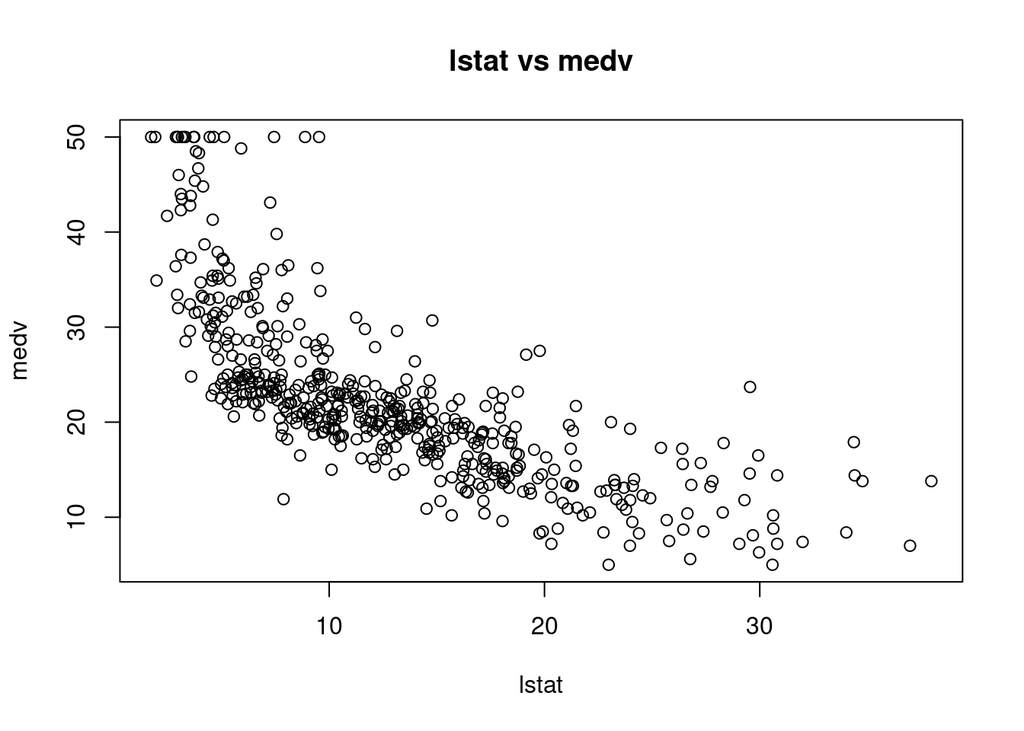

```r
plot(lstat, medv, main = "lstat vs medv")
```

# Modelo Lineal Simple

En este caso si se escribe primero la variable dependiente y después la independiente Siempre hay que poner summary.

```r
modelo1 <- lm(medv ~ lstat)
summary(modelo1)
```

```
##
## Call:
## lm(formula = medv ~ lstat)
##
## Residuals:
##     Min      1Q  Median      3Q     Max
## -15.168  -3.990  -1.318   2.034  24.500
##
## Coefficients:
##             Estimate Std. Error t value Pr(>|t|)
## (Intercept) 34.55384    0.56263   61.41   <2e-16 ***
## lstat       -0.95005    0.03873  -24.53   <2e-16 ***
## ---
## Signif. codes:  0 '***' 0.001 '**' 0.01 '*' 0.05 '.' 0.1 ' ' 1
##
## Residual standard error: 6.216 on 504 degrees of freedom
## Multiple R-squared:  0.5441, Adjusted R-squared:  0.5432
## F-statistic: 601.6 on 1 and 504 DF,  p-value: < 2.2e-16
```